# Final Report: STA141A, Predicting Wildfire Incidence in the United States

Jocelyn Chang

## Data:

This report will contain information from 2 different data sets.

You can find and download a subset of historical wildfire records derived from the Kaggle dataset *“[188 Million US Wildfires](https://www.kaggle.com/datasets/rtatman/188-million-us-wildfires/data)”*. The dataset includes wildfire ignition locations, discovery dates, containment dates, and final burned area across the contiguous United States.

Wildfires vary widely in size, and the vast majority of recorded fires are very small and quickly contained. Modeling all recorded fires would lead to extreme class imbalance and would obscure the dynamics of fires that are operationally and scientifically meaningful.

To address this, I filtered the raw wildfire records to retain only “notable” fires. The cutoff retained only the wildfires with final burned area $\geq$ 300 acres. This threshold is consistent with operational wildfire reporting standards used by U.S. fire management agencies, where *large wildland fires* are commonly defined as: $\geq$ 100 acres in timber fuel models, or $\geq$ 300 acres in grass or brush fuel models

From my midquarter project report, I imported some additional data where I requested some data from the [NOAA](https://www.ncei.noaa.gov/access/monitoring/wildfires/), I looked at 5 states with either high fire size or fire count: Kansas, California, Nevada, Georgia, and Texas. There are 3 weather stations for the 5 states, each in different major cities of the overall state. The dataset contains a little over 100k entries, spanning 1992-2015, adjusted to the first wildfire dataset implemented by the professor. A description of the variables in the [dataset](https://drive.google.com/file/d/1SYw3ipYghvctdo_Ht4ii-BAc8yYUEYIG/view?usp=sharing) is available on this on the [NOAA metadata](https://www.ncei.noaa.gov/products/land-based-station/global-historical-climatology-network-daily?utm_source=chatgpt.com), via this [document](https://www.ncei.noaa.gov/data/global-historical-climatology-network-daily/doc/GHCND_documentation.pdf).

To download the weather data, click [here](https://drive.google.com/file/d/12ls-6jFRglZYt3jKU6PbdP0EuGO3ro5i/view?usp=sharing) or find it in the repo under Data/weather.csv.

## Background:

Over recent years, area burned by wildfires have increased, partially due to a few reasons, rising temperatures, longer drought durations, etc. Therefore, having an accurate way of predicting when and where larger wildfires are likely to break out is one of great importance, can could help aid efforts in resource allocation, preparation, evacuation planning, etc.

This project is focused on developing a prediction model for notable wildfire incidences using the Fire Program Analysis Fire-Occurrence Database, a comprehensive record of wildfires reported across the US from 1992 to 2015. I will be using this data set to predict whether at least one notable wildfire will occur in that cell during the following month. In addition, I have found records with weather observations from NOAA stations across five high fire-risk states (California, Nevada, Kansas, Georgia, and Texas), containing variables like temperature, wind, and precipitation. In particular, I will be exploring the [boom and bust cycle](https://time.com/7205644/los-angeles-california-fires-climate-change/) theory. The idea that prior rainfall promotes greenry growth & “dead leaves, trees and other tinder that gets left behind when things dry” becomes fuel that result in wildfires by looking at lagged precipitation elements and examining their relationship with fire occurrence in the following analysis.

### 1. Data Preprocessing

Step 1: ID and filter the notable fires

Wildfires can vary in size, so a large amount of recorded fires are very small and contained quickly. Because I am trying to predict fires for the purpose of better resource allocation, planning, etc. It makes more sense to only retain notable fires with at least 300 acres burned in the data set. This leads to 25,666 notable fire records left over.

```r
#install.packages("RSQLite")
#install.packages("DBI")
#install.packages("pROC")
#install.packages("slider")
#install.packages("xgboost")
setwd("~/Desktop/STA141AW26")
#getwd()
library(DBI)
library(RSQLite)

con <- dbConnect(SQLite(), "Data/FPA_FOD_20170508.sqlite")

wildfires <- dbReadTable(con, "Fires")
dbDisconnect(con) #alr loaded data
library(dplyr)

suppressMessages({
    library(dplyr)
    library(ggplot2)
    library(tidyverse)
    library(slider)
    library(pROC)
    library(scales)
    library(lubridate)
    library(maps)
    library(viridis)
    library(xgboost)
    library(Matrix)
    library(DBI)
    library(RSQLite)})

weather <- read.csv("Data/weather.csv")


#dates for the ds
fires <- wildfires |> mutate(FIRE_DATE = as.Date(paste(FIRE_YEAR, DISCOVERY_DOY, sep = "-"), format = "%Y-%j"), YEAR = year(FIRE_DATE), MONTH = month(FIRE_DATE))

#filter for the 300 acre thres
imp_threshold_acres <- 300
imp_fires <- fires |> filter(FIRE_SIZE >= imp_threshold_acres)

nrow(imp_fires)
```

```
## [1] 25666
```

Step 2. Space & Time

Each fire is assigned to a 1° × 1° grid cell (squares) so I can predict whether each square will have a fire next month. Having these grid cells allow for modeling to be small but capture geographic variation in fire risk.

```r
#spatial & time
imp_fires <- imp_fires |>
  mutate(lat_bin = floor(LATITUDE), lon_bin = floor(LONGITUDE), ym = YEAR * 100 + MONTH)
```

Step 3. Panel building

Making it so we count the amount of fires per square per month. In addition, for squares with no fires that month have a 0 rather than a blank space, so it isn’t counted as missing data. This is important so I can determine what is fire versus non-fire conditions. Therefore, Grid cell-months with no recorded fires receive n_fires = 0 and fire_this_month = 0.

```r
# grid x month
grid_month_fire <- imp_fires |> group_by(lat_bin, lon_bin, ym) |>
  summarise(n_fires = n(), .groups = "drop") |>
  mutate(fire_this_month = 1L)

head(grid_month_fire)
```

```
## # A tibble: 6 × 5
##   lat_bin lon_bin     ym n_fires fire_this_month
##     <dbl>   <dbl>  <dbl>   <int>           <int>
## 1      17     -68 200502       2               1
## 2      17     -68 200701       1               1
## 3      17     -68 200703       2               1
## 4      17     -68 201101       1               1
## 5      17     -68 201102       1               1
## 6      17     -67 200303       1               1
```

```r
# full panel
all_grids <- grid_month_fire |> distinct(lat_bin, lon_bin)

start_date <- ymd(paste0(min(grid_month_fire$ym) %/% 100, "-", min(grid_month_fire$ym) %% 100, "-01"))
end_date <- ymd(paste0(max(grid_month_fire$ym) %/% 100, "-",max(grid_month_fire$ym) %% 100, "-01"))

all_months <- tibble(date = seq.Date(start_date, end_date, by = "month")) |>
  mutate(year = year(date),
         month = month(date),
         ym = year * 100 + month) |>
  select(ym, year, month)

panel <- crossing(all_grids, all_months) |>
  left_join(grid_month_fire, by = c("lat_bin", "lon_bin", "ym")) |>
  mutate(n_fires = replace_na(n_fires, 0L),
         fire_this_month = replace_na(fire_this_month, 0L))

glimpse(panel)
```

```
## Rows: 283,680
## Columns: 7
## $ lat_bin         <dbl> 17, 17, 17, 17, 17, 17, 17, 17, 17, 17, 17, 17, 17, 17…
## $ lon_bin         <dbl> -68, -68, -68, -68, -68, -68, -68, -68, -68, -68, -68,…
## $ ym              <dbl> 199201, 199202, 199203, 199204, 199205, 199206, 199207…
## $ year            <dbl> 1992, 1992, 1992, 1992, 1992, 1992, 1992, 1992, 1992, …
## $ month           <dbl> 1, 2, 3, 4, 5, 6, 7, 8, 9, 10, 11, 12, 1, 2, 3, 4, 5, …
## $ n_fires         <int> 0, 0, 0, 0, 0, 0, 0, 0, 0, 0, 0, 0, 0, 0, 0, 0, 0, 0, …
## $ fire_this_month <int> 0, 0, 0, 0, 0, 0, 0, 0, 0, 0, 0, 0, 0, 0, 0, 0, 0, 0, …
```

Step 4. Binary Variable

y_next shows whether at least one notable fire occurs in a given grid cell in the *next* month. This way, I can predicting future fire occurrence from current conditions.

```r
#next month, pred future fires
panel <- panel |> arrange(lat_bin, lon_bin, ym) |>
  group_by(lat_bin, lon_bin) |>
  mutate(y_next = lead(fire_this_month, n = 1L)) |>
  ungroup() |>
  filter(!is.na(y_next))

table(panel$y_next)
```

```
##
##      0      1
## 267345  15350
```

Step 5. Predictors

A lot of predictors are being created:

1. Geographic: lat_bin, lon_bin, and state are used to capture the spatial location of each grid cell
2. Seasonal: using sine and cosine transformations to capture the cyclical pattern of seasons
3. Fire history: using lad to find the historical fire behavior of each grid cell: number after lag represents the fire count n months prior. (ex. fire_lag12 is the fire count exactly 12 months prior, number after fire_roll represents the rolling sums of fire counts, number after size_roll is the rolling sums of total burned area. All these factors allow me to see fire risk across time.

```r
#state to grid
mode_state <- function(x) {
  names(sort(table(x), decreasing = TRUE))[1]}

grid_state <- imp_fires |>
  group_by(lat_bin, lon_bin) |>
  summarise(state = mode_state(STATE), .groups = "drop")

panel <- panel |>
  left_join(grid_state, by = c("lat_bin", "lon_bin"))

panel |> select(state) |> summary()
```

```
##     state
##  Length:282695
##  Class :character
##  Mode  :character
```

```r
#season
panel <- panel |>
  mutate(month_sin = sin(2 * pi * month/ 12),
         month_cos = cos(2 * pi * month /12))

panel |> select(month_sin, month_cos) |> head()
```

```
## # A tibble: 6 × 2
##   month_sin month_cos
##       <dbl>     <dbl>
## 1  5   e- 1  8.66e- 1
## 2  8.66e- 1  5   e- 1
## 3  1   e+ 0  6.12e-17
## 4  8.66e- 1 -5   e- 1
## 5  5   e- 1 -8.66e- 1
## 6  1.22e-16 -1   e+ 0
```

```r
grid_fire_size <- imp_fires |>
  group_by(lat_bin, lon_bin, ym) |>
  summarise(fire_size = sum(FIRE_SIZE), .groups = "drop")

panel <- panel |>
  left_join(grid_fire_size, by = c("lat_bin", "lon_bin", "ym")) |>
  mutate(fire_size = coalesce(fire_size, 0))

panel <- panel |>
  arrange(lat_bin, lon_bin, ym) |>
  group_by(lat_bin, lon_bin) |>
  mutate(fire_lag12 = lag(n_fires, 12),
         fire_roll3 = slide_dbl(n_fires, sum, .before = 2, .complete = FALSE),
         fire_roll12 = slide_dbl(n_fires, sum, .before = 11, .complete = FALSE),
         size_roll3 = slide_dbl(fire_size, sum, .before = 2, .complete = FALSE),
         size_roll12 = slide_dbl(fire_size, sum, .before = 11, .complete = FALSE)) |>
  ungroup()

panel |>
  select(n_fires, fire_lag12, fire_roll3, fire_roll12,
         size_roll3, size_roll12) |>
  summary()
```

```
##     n_fires           fire_lag12        fire_roll3       fire_roll12
##  Min.   : 0.00000   Min.   : 0.0000   Min.   : 0.0000   Min.   : 0.000
##  1st Qu.: 0.00000   1st Qu.: 0.0000   1st Qu.: 0.0000   1st Qu.: 0.000
##  Median : 0.00000   Median : 0.0000   Median : 0.0000   Median : 0.000
##  Mean   : 0.09077   Mean   : 0.0903   Mean   : 0.2719   Mean   : 1.063
##  3rd Qu.: 0.00000   3rd Qu.: 0.0000   3rd Qu.: 0.0000   3rd Qu.: 1.000
##  Max.   :44.00000   Max.   :44.0000   Max.   :63.0000   Max.   :72.000
##                     NA's   :11820
##    size_roll3      size_roll12
##  Min.   :     0   Min.   :     0
##  1st Qu.:     0   1st Qu.:     0
##  Median :     0   Median :     0
##  Mean   :  1349   Mean   :  5168
##  3rd Qu.:     0   3rd Qu.:  1000
##  Max.   :606945   Max.   :606945
##
```

```r
glimpse(panel)
```

```
## Rows: 282,695
## Columns: 17
## $ lat_bin         <dbl> 17, 17, 17, 17, 17, 17, 17, 17, 17, 17, 17, 17, 17, 17…
## $ lon_bin         <dbl> -68, -68, -68, -68, -68, -68, -68, -68, -68, -68, -68,…
## $ ym              <dbl> 199201, 199202, 199203, 199204, 199205, 199206, 199207…
## $ year            <dbl> 1992, 1992, 1992, 1992, 1992, 1992, 1992, 1992, 1992, …
## $ month           <dbl> 1, 2, 3, 4, 5, 6, 7, 8, 9, 10, 11, 12, 1, 2, 3, 4, 5, …
## $ n_fires         <int> 0, 0, 0, 0, 0, 0, 0, 0, 0, 0, 0, 0, 0, 0, 0, 0, 0, 0, …
## $ fire_this_month <int> 0, 0, 0, 0, 0, 0, 0, 0, 0, 0, 0, 0, 0, 0, 0, 0, 0, 0, …
## $ y_next          <int> 0, 0, 0, 0, 0, 0, 0, 0, 0, 0, 0, 0, 0, 0, 0, 0, 0, 0, …
## $ state           <chr> "PR", "PR", "PR", "PR", "PR", "PR", "PR", "PR", "PR", …
## $ month_sin       <dbl> 5.000000e-01, 8.660254e-01, 1.000000e+00, 8.660254e-01…
## $ month_cos       <dbl> 8.660254e-01, 5.000000e-01, 6.123234e-17, -5.000000e-0…
## $ fire_size       <dbl> 0, 0, 0, 0, 0, 0, 0, 0, 0, 0, 0, 0, 0, 0, 0, 0, 0, 0, …
## $ fire_lag12      <int> NA, NA, NA, NA, NA, NA, NA, NA, NA, NA, NA, NA, 0, 0, …
## $ fire_roll3      <dbl> 0, 0, 0, 0, 0, 0, 0, 0, 0, 0, 0, 0, 0, 0, 0, 0, 0, 0, …
## $ fire_roll12     <dbl> 0, 0, 0, 0, 0, 0, 0, 0, 0, 0, 0, 0, 0, 0, 0, 0, 0, 0, …
## $ size_roll3      <dbl> 0, 0, 0, 0, 0, 0, 0, 0, 0, 0, 0, 0, 0, 0, 0, 0, 0, 0, …
## $ size_roll12     <dbl> 0, 0, 0, 0, 0, 0, 0, 0, 0, 0, 0, 0, 0, 0, 0, 0, 0, 0, …
```

Step 6. Adding weather

Adding monthly weather observations from 15 NOAA stations across California, Nevada, Kansas, Georgia, and Texas. Each state-month will have maximum and minimum temperature, total precipitation, and average wind speed. Also, there is also lagged precipitation elements to capture the boom and bust cycle.

```r
station_to_state <- c("CARSON CITY, NV US" = "NV",
                      "RENO AIRPORT, NV US" = "NV",
                      "MCCARRAN INTERNATIONAL AIRPORT, NV US" = "NV",
                      "TOPEKA FORBES FIELD, KS US" = "KS",
                      "DODGE CITY REGIONAL AIRPORT, KS US" = "KS",
                      "WICHITA DWIGHT D. EISENHOWER NATIONAL AIRPORT, KS US" = "KS",
                      "ATLANTA HARTSFIELD JACKSON INTERNATIONAL AIRPORT, GA US" = "GA",
                      "COLUMBUS METROPOLITAN AIRPORT, GA US" = "GA",
                      "SAVANNAH HILTON HEAD INTERNATIONAL AIRPORT, GA US" = "GA",
                      "HOUSTON INTERCONTINENTAL AIRPORT, TX US" = "TX",
                      "AUSTIN BERGSTROM INTERNATIONAL AIRPORT, TX US" = "TX",
                      "SAN ANTONIO INTERNATIONAL AIRPORT, TX US" = "TX",
                      "LOS ANGELES INTERNATIONAL AIRPORT, CA US" = "CA",
                      "SAN DIEGO INTERNATIONAL AIRPORT, CA US" = "CA",
                      "SAN FRANCISCO INTERNATIONAL AIRPORT, CA US" = "CA") #from last mid qtr report

weather_agg <- weather |>
  mutate(state = recode(NAME, !!!station_to_state),#splicing so i dont need to rewrite all the stations
         DATE = ymd(DATE),
         year = year(DATE),
         month = month(DATE),
         ym= year * 100 + month) |>
  filter(!is.na(state)) |>
  group_by(state, ym, year, month) |>
  summarise(
    avg_tmax = mean(TMAX, na.rm = TRUE), #avg daily max temp
    avg_tmin = mean(TMIN, na.rm = TRUE),#avg daily min temp
    total_prcp = sum(PRCP,  na.rm = TRUE), #annual total precipitation
    avg_wind = mean(AWND, na.rm = TRUE), #avg wind speed
    .groups = "drop") |>
  #lag rain
  arrange(state, ym) |>
  group_by(state) |>
  mutate(prcp_lag1= lag(total_prcp, 1), #prev month rain
         prcp_lag3= lag(total_prcp, 3), #3 month prior
         prcp_lag6= lag(total_prcp, 6), #6 month prior
         prcp_roll3 = slide_dbl(total_prcp, mean, .before = 2, .complete = FALSE)) |>
  ungroup()



panel <- panel |>
  left_join(weather_agg, by = c("state", "ym", "year", "month"))
```

Step 7. Summary table describing the final data set

Final data set has 282695 monthly grid cell observations from 1992 to 2015, with 20 predictors and a binary outcome showing whether there is a notable fire occurrence in the following month.

```r
final_df <- panel |>
  mutate(y_next = factor(y_next, levels = c(0, 1))) |>
  select(y_next, lat_bin, lon_bin, state,
         month_cos, month_sin, year,
         n_fires, fire_lag12, fire_roll3, fire_roll12,
         size_roll3, size_roll12,
         avg_tmax, avg_tmin, total_prcp, avg_wind, #weather add
         prcp_lag1, prcp_lag3, prcp_lag6, prcp_roll3)  #lag precip

# summary table based off of discussion
dataset_summary <- tibble(
  n_rows = nrow(final_df),
  year_min = min(panel$year),
  year_max = max(panel$year),
  spatial_unit = "1° x 1° lat-lon grid (floor bins)",
  temporal_unit = "monthly",
  outcome = "y_next = 1 if any notable fire occurs in grid cell next month",
  predictors = "lat_bin, lon_bin, state, month_cos, month_sin, year,
    n_fires, fire_lag12, fire_roll3, fire_roll12, size_roll3, size_roll12, avg_tmax,
  avg_tmin, total_prcp, avg_wind, prcp_lag1, prcp_lag3, prcp_lag6, prcp_roll3")


dataset_summary
```

```
## # A tibble: 1 × 7
##   n_rows year_min year_max spatial_unit         temporal_unit outcome predictors
##    <int>    <dbl>    <dbl> <chr>                <chr>         <chr>   <chr>
## 1 282695     1992     2015 1° x 1° lat-lon gri… monthly       y_next… "lat_bin,…
```

### 2. Exploratory Data Analysis

Plot 1: Spatial Map: How does wildfire incidence vary across space?

The US has different conditions depending on the region you are in, like climate zones, crop types, etc. This plot shows fire risk is heavily concentrated in the western states, particularly California and the Northwest area, while the eastern US shows much lower rates, except for Florida.

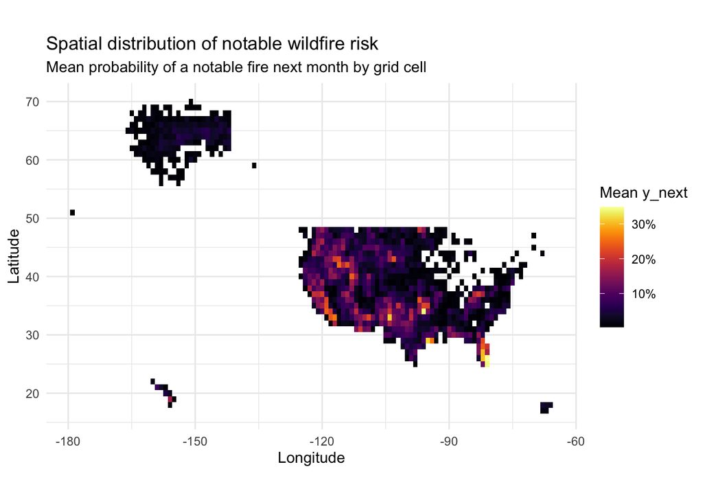

```r
#spatical
eda_spatial <- panel |>
  group_by(lat_bin, lon_bin) |>
  summarise(fire_rate = mean(y_next == 1), .groups = "drop")

ggplot(eda_spatial, aes(x = lon_bin, y = lat_bin, fill = fire_rate)) +
  geom_tile() +
  scale_fill_viridis(option = "inferno",
                     labels = scales::percent) + #making things percentage so its easier to read
  coord_quickmap() + #from discussion, i took out the xlim = c(-125, -65), ylim = c(25, 50) bc it didnt include alaska and hawaii
  labs(title = "Spatial distribution of notable wildfire risk",
       subtitle = "Mean probability of a notable fire next month by grid cell",
       x = "Longitude", y = "Latitude", fill = "Mean y_next") +
  theme_minimal()
```

Plot 2: Seasonality graph: How important is the season for wildfires?

Fire behavior is affected by factors like temperature, humidity, greenery dryness, which are all impacted by the seasonal cycles. So fire risk would likely vary by time of year. This plot shows a peak in June & July, which are hot and dry summer conditions. Additionally, there is also some movement in Feburary and March, which is interesting.

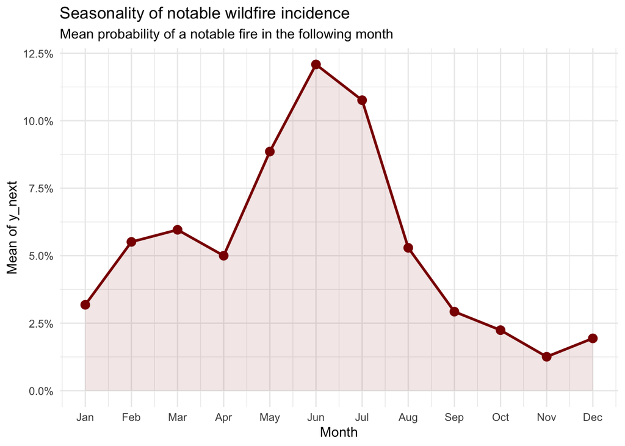

```r
#seasons
eda_month <- panel |>
  group_by(month) |>
  summarise(mean_y_next = mean(y_next == 1), .groups = "drop")

ggplot(eda_month, aes(x = month, y = mean_y_next)) +
  geom_line(linewidth = 1, color = "darkred") +
  geom_point(size = 3, color = "darkred") +
  geom_area(alpha = 0.1, fill = "darkred") + #under the curve shadeing
  scale_x_continuous(breaks = 1:12,
                     labels = c("Jan","Feb","Mar","Apr","May","Jun",
                                "Jul","Aug","Sep","Oct","Nov","Dec")) +
  scale_y_continuous(labels = scales::percent) + #percentage
  labs(title = "Seasonality of notable wildfire incidence",
       subtitle = "Mean probability of a notable fire in the following month",
       x = "Month", y = "Mean of y_next") + theme_minimal()
```

Plot 3: Precipitation bar chart: How do predictors differ between fire and non-fire observations?

From the boom and bust cycle theory, prior rainfall is hypothesized to influence fire risk. To see if this is a possible effect, I compared the fire rates across precipitation 3 months prior. The grid cells in Q2 how the highest fire rate, rather than the driest quartile (Q1). This is pretty consistent with the boom and bust cycle hypothesis, that some prior rainfall promotes greenery growth which later dries into fuel for fires. And that an extreme drought would stop greenery growth completely, leaving less fuel for the fires. This non-linear relationship shows that I should use lagged precipitation as a predictor.

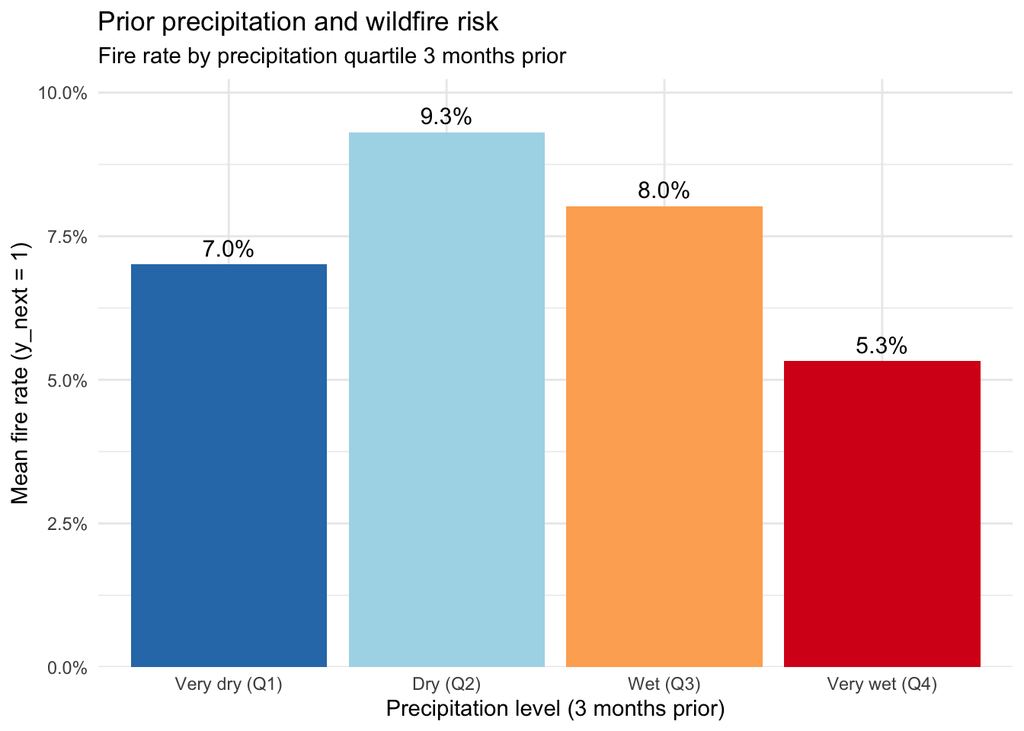

```r
#theory the prof was talking about that after rain there is a larger fire (googled and it was the boom and bust cycle thry)
panel |>
  filter(!is.na(prcp_lag3)) |>
  mutate(prcp_bucket = ntile(prcp_lag3, 4),
         prcp_label = case_when(
           prcp_bucket == 1 ~ "Very dry (Q1)",
           prcp_bucket == 2 ~ "Dry (Q2)",
           prcp_bucket == 3 ~ "Wet (Q3)",
           prcp_bucket == 4 ~ "Very wet (Q4)"
         ),
         prcp_label = factor(prcp_label,
                             levels = c("Very dry (Q1)", "Dry (Q2)",
                                        "Wet (Q3)", "Very wet (Q4)"))) |>
  group_by(prcp_label) |>
  summarise(fire_rate = mean(y_next == 1), .groups = "drop") |>
  ggplot(aes(x = prcp_label, y = fire_rate, fill = prcp_label)) +
  geom_col(show.legend = FALSE) +
  geom_text(aes(label = scales::percent(fire_rate, accuracy = 0.1)), vjust = -0.5, size = 4) + #adding percentage
  scale_fill_brewer(palette = "RdYlBu", direction = -1) +
  scale_y_continuous(labels = scales::percent, expand = expansion(mult = c(0, 0.1))) +  #labels
  labs(title = "Prior precipitation and wildfire risk",
       subtitle = "Fire rate by precipitation quartile 3 months prior",
       x = "Precipitation level (3 months prior)",
       y = "Mean fire rate (y_next = 1)") +
  theme_minimal()
```

Plot 4: Year chart: Are there trends in wildfires over time?

Climate change [research](https://www.c2es.org/content/wildfires-and-climate-change/#:~:text=Wildfires%20are%20becoming%20more%20frequent,the%20rate%20of%20fire%20spread.) shows that increasing temperatures have more frequent droughts that increase wildfires overtime. To see if this is true, I plotted mean monthly fire probability by year. The plot shows that there is a positive trend from 1992 to 2015, with some variability form year to year. But overall, mean monthly fire probability goes from ~3.5% in 1992 to 6.2% in 2015, showing that there is an increasing wildfire risk over the study period

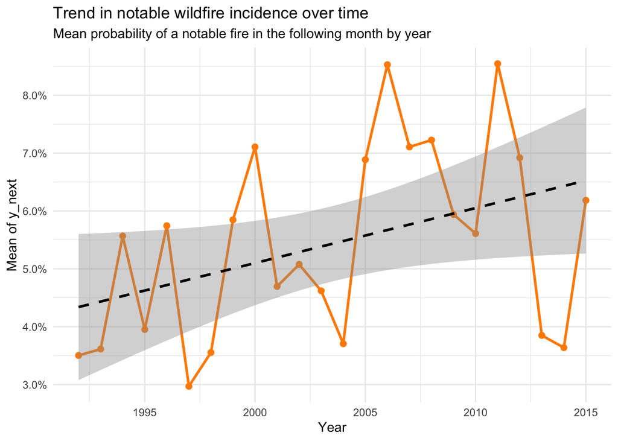

```r
#year trend
eda_year <- panel |>
  group_by(year) |>
  summarise(mean_y_next = mean(y_next == 1), .groups = "drop")

ggplot(eda_year, aes(x = year, y = mean_y_next)) +
  geom_line(linewidth = 1, color = "darkorange") +
  geom_point(size = 2, color = "darkorange") +
  geom_smooth(method = "lm", se = TRUE,
              color = "black", linetype = "dashed") +
  scale_y_continuous(labels = scales::percent) +
  labs(title = "Trend in notable wildfire incidence over time",
       subtitle = "Mean probability of a notable fire in the following month by year",
       x = "Year", y = "Mean of y_next") +
  theme_minimal()
```

### 3. Modeling

**Baseline: Logistic Regression**

- Logistic Regression, models the log-odds of a notable fire occurring next month as a linear combination of all predictors. Logistic regression is easy to understand which predictors are associated with increased fire risk.

$$\log\left(\frac{p}{1-p}\right) = \beta_0
+ \sum_{j=1}^{20} \beta_j x_j$$

where $p = P(y_{\text{next}} = 1 \mid x)$ and $x_j$ represents each of the 20 predictors.

**Additional Model: LASSO**

- Since we have a lot of predictors, 20, I thought that using a LASSO model might be interesting to see which ones were more important. It’s also a model format I’m familiar with because of STA108, so I thought that it would be interesting to apply it here as well. LASSO adds a penalty term that shrinks coefficients from unimportant predictors exactly to zero

$$-\ell(\beta) + \lambda \sum_{j=1}^{20}
|\beta_j|$$

where $\lambda$ controls the strength of regularization and is selected by cross validation (CV). Weak predictors are shrunk exactly to zero.

**Additional Model: RandomForest**

- The third model is a Random Forest. Each tree is trained on a bootstrap sample of the training data, and predictions are averaged across all trees. This especially good for the work I’ve done so far because
  - The non-linear relationship between prior precipitation and fire risk observed in Section 2 suggests a linear model may be insufficient to capture the full effort
  - Random Forest naturally captures interactions between predictors such as temperature and drought without requiring a lot of tweaking

$$\hat{p}_i = \frac{1}{B} \sum_{b=1}^{B}
T_b(x_i)$$

where $T_b$ is the $b$-th decision tree trained on bootstrap sample $b$ and $B$ is the total number of trees.

```r
glimpse(final_df) #in the discussion notes, but i alr wrote it in
```

```
## Rows: 282,695
## Columns: 21
## $ y_next      <fct> 0, 0, 0, 0, 0, 0, 0, 0, 0, 0, 0, 0, 0, 0, 0, 0, 0, 0, 0, 0…
## $ lat_bin     <dbl> 17, 17, 17, 17, 17, 17, 17, 17, 17, 17, 17, 17, 17, 17, 17…
## $ lon_bin     <dbl> -68, -68, -68, -68, -68, -68, -68, -68, -68, -68, -68, -68…
## $ state       <chr> "PR", "PR", "PR", "PR", "PR", "PR", "PR", "PR", "PR", "PR"…
## $ month_cos   <dbl> 8.660254e-01, 5.000000e-01, 6.123234e-17, -5.000000e-01, -…
## $ month_sin   <dbl> 5.000000e-01, 8.660254e-01, 1.000000e+00, 8.660254e-01, 5.…
## $ year        <dbl> 1992, 1992, 1992, 1992, 1992, 1992, 1992, 1992, 1992, 1992…
## $ n_fires     <int> 0, 0, 0, 0, 0, 0, 0, 0, 0, 0, 0, 0, 0, 0, 0, 0, 0, 0, 0, 0…
## $ fire_lag12  <int> NA, NA, NA, NA, NA, NA, NA, NA, NA, NA, NA, NA, 0, 0, 0, 0…
## $ fire_roll3  <dbl> 0, 0, 0, 0, 0, 0, 0, 0, 0, 0, 0, 0, 0, 0, 0, 0, 0, 0, 0, 0…
## $ fire_roll12 <dbl> 0, 0, 0, 0, 0, 0, 0, 0, 0, 0, 0, 0, 0, 0, 0, 0, 0, 0, 0, 0…
## $ size_roll3  <dbl> 0, 0, 0, 0, 0, 0, 0, 0, 0, 0, 0, 0, 0, 0, 0, 0, 0, 0, 0, 0…
## $ size_roll12 <dbl> 0, 0, 0, 0, 0, 0, 0, 0, 0, 0, 0, 0, 0, 0, 0, 0, 0, 0, 0, 0…
## $ avg_tmax    <dbl> NA, NA, NA, NA, NA, NA, NA, NA, NA, NA, NA, NA, NA, NA, NA…
## $ avg_tmin    <dbl> NA, NA, NA, NA, NA, NA, NA, NA, NA, NA, NA, NA, NA, NA, NA…
## $ total_prcp  <dbl> NA, NA, NA, NA, NA, NA, NA, NA, NA, NA, NA, NA, NA, NA, NA…
## $ avg_wind    <dbl> NA, NA, NA, NA, NA, NA, NA, NA, NA, NA, NA, NA, NA, NA, NA…
## $ prcp_lag1   <dbl> NA, NA, NA, NA, NA, NA, NA, NA, NA, NA, NA, NA, NA, NA, NA…
## $ prcp_lag3   <dbl> NA, NA, NA, NA, NA, NA, NA, NA, NA, NA, NA, NA, NA, NA, NA…
## $ prcp_lag6   <dbl> NA, NA, NA, NA, NA, NA, NA, NA, NA, NA, NA, NA, NA, NA, NA…
## $ prcp_roll3  <dbl> NA, NA, NA, NA, NA, NA, NA, NA, NA, NA, NA, NA, NA, NA, NA…
```

```r
#for log regression in the base,
log_reg <- y_next ~ lat_bin + lon_bin + state + month_cos + month_sin + year +
  n_fires + fire_lag12 + fire_roll3 + fire_roll12 + size_roll3 + size_roll12 +
  avg_tmax + avg_tmin + total_prcp + avg_wind + prcp_lag1 + prcp_lag3 + prcp_lag6 + prcp_roll3


library(glmnet)
library(randomForest)
```

### 4. Model Fitting and Validation

Time-aware CV:

Since standard CV just randomly puts data into folds, this would be bad for the modeling that I want to tain from past years to predict the future. And if it was random, then there is a chance of the reverse happening (this is a form of data leakage). Instead, for each validation year, the model is only trained on prior years and tested on the year that was held. This ensures that the ordering of the data is how the model would actually be used in real life (predicting future fires from past observations!)

AUC:

Area Under the ROC curve is the primary performance metric I can going to use. It measures the how well the model separates fire months from nonfire months (so a score of 1.0 means perfect separation, and 0.5 means the model is basically randomly guessing). The data set is heavily imbalanced (15350/282695) ~5% of observations are fires. AUC avoids this problem by measuring how well the model ranks fire versus nonfire observations regardless of how rare fires are.

Best Performance:

```r
years_sorted <- sort(unique(final_df$year))
min_train_years <- 3
set.seed(9)

#time cv, dont use furture data to pred the past
fold_results <- tibble(
  train_end_year = years_sorted[(min_train_years):(length(years_sorted) - 2)],
  valid_year = years_sorted[(min_train_years + 1):(length(years_sorted) - 1)]
) |> #log reg, split tain and validation sets by yr
  mutate(auc_glm = map2_dbl(train_end_year, valid_year, function(tr_end, va_year) {
      train <- final_df |> filter(year <= tr_end) |> drop_na()
      valid <- final_df |> filter(year == va_year) |> drop_na()
      #fitting log reg with all 20 pred
      fit <- glm(log_reg, data = train, family = binomial, na.action = na.exclude)
      p_hat <- predict(fit, newdata = valid, type = "response")
      #auc calc, how well model ranks fire v. nonfire months
      roc_obj <- roc(response = valid$y_next, predictor = p_hat, quiet = TRUE)
      as.numeric(auc(roc_obj))}),
#LASSO
        auc_lasso = map2_dbl(train_end_year, valid_year, function(tr_end, va_year) {
      train <- final_df |> filter(year <= tr_end) |> drop_na()
      valid <- final_df |> filter(year == va_year) |> drop_na()
      #uses matric instead of formula, state into dummy variables
      X_train <- model.matrix(log_reg, data = train)[, -1]
      y_train <- as.numeric(as.character(train$y_next))
      X_valid <- model.matrix(log_reg, data = valid)[, -1]
      #finding opt lambda via cv
      cv_fit <- cv.glmnet(X_train, y_train,
                          family = "binomial", alpha = 1, nfolds= 5,
                          type.measure = "auc")
      p_hat <- predict(cv_fit, newx = X_valid, s = "lambda.min", type = "response")[, 1]
      roc_obj <- roc(response = valid$y_next, predictor = p_hat, quiet = TRUE)
      as.numeric(auc(roc_obj))}),
#random forest
    auc_rf = map2_dbl(train_end_year, valid_year, function(tr_end, va_year) {
      train <- final_df |> filter(year <= tr_end) |> drop_na()
      valid <- final_df |> filter(year == va_year) |> drop_na()
      fit <- randomForest(log_reg, data = train, ntree = 100, mtry  = 4) #100 trees
      p_hat <- predict(fit, newdata = valid, type = "prob")[, "1"]
      roc_obj <- roc(response = valid$y_next, predictor = p_hat, quiet = TRUE)
      as.numeric(auc(roc_obj))}))

fold_results
```

```
## # A tibble: 20 × 5
##    train_end_year valid_year auc_glm auc_lasso auc_rf
##             <dbl>      <dbl>   <dbl>     <dbl>  <dbl>
##  1           1994       1995   0.839     0.839  0.867
##  2           1995       1996   0.853     0.851  0.852
##  3           1996       1997   0.874     0.875  0.897
##  4           1997       1998   0.841     0.843  0.860
##  5           1998       1999   0.844     0.843  0.831
##  6           1999       2000   0.833     0.832  0.816
##  7           2000       2001   0.872     0.872  0.845
##  8           2001       2002   0.810     0.810  0.834
##  9           2002       2003   0.866     0.865  0.833
## 10           2003       2004   0.840     0.839  0.866
## 11           2004       2005   0.773     0.772  0.764
## 12           2005       2006   0.779     0.779  0.783
## 13           2006       2007   0.719     0.719  0.699
## 14           2007       2008   0.795     0.796  0.832
## 15           2008       2009   0.844     0.845  0.856
## 16           2009       2010   0.703     0.705  0.777
## 17           2010       2011   0.797     0.798  0.809
## 18           2011       2012   0.779     0.780  0.789
## 19           2012       2013   0.813     0.812  0.808
## 20           2013       2014   0.729     0.731  0.780
```

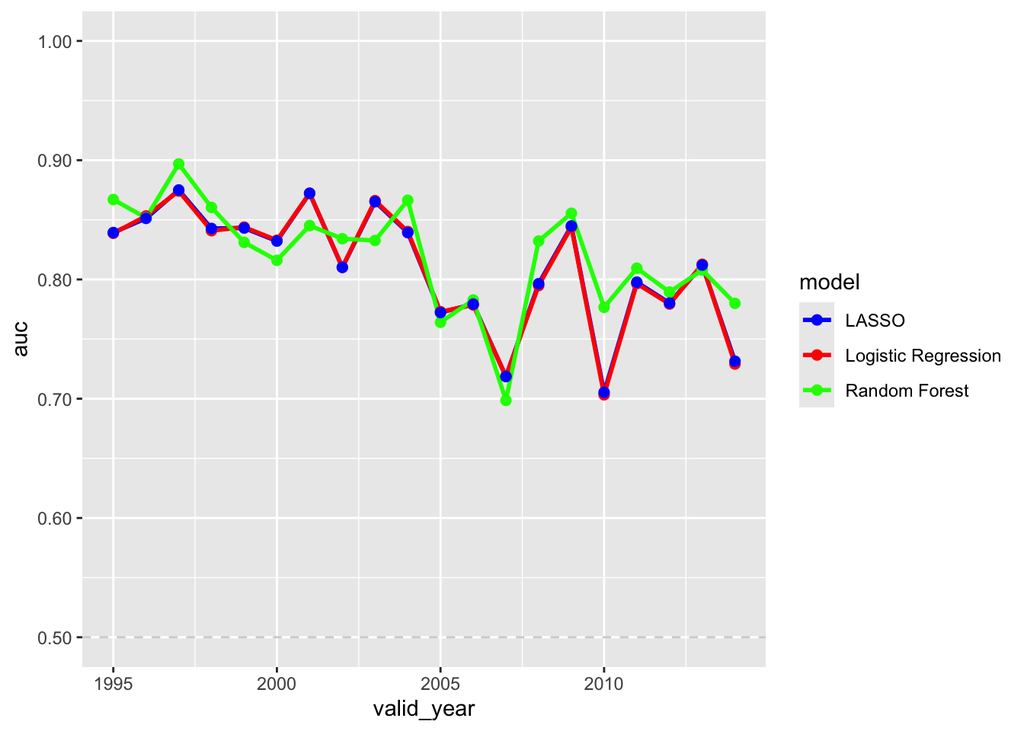

```r
#AUC over time
fold_long <- fold_results |>
  pivot_longer(cols = c(auc_glm, auc_rf, auc_lasso),
               names_to = "model",
               values_to = "auc") |>
  mutate(model = recode(model,
                        "auc_glm" = "Logistic Regression",
                        "auc_rf"= "Random Forest",
                        "auc_lasso" = "LASSO"))
#long so i can plot on the same. axes
ggplot(fold_long, aes(x = valid_year, y = auc, color = model)) +
  geom_line(linewidth = 1) +
  geom_point(size = 2) +
  geom_hline(yintercept = 0.5, linetype = "dashed",
             color = "gray", alpha = 0.7) +  # shows random baseline
  scale_y_continuous(limits = c(0.5, 1),        # anchors at 0.5 (random guessing)
                     labels = scales::number_format(accuracy = 0.01)) +
   scale_color_manual(values = c("Logistic Regression" = "red",
                                "LASSO" = "blue",
                                "Random Forest" = "green"))
```